# Event study design: How normalisation affects estimation and inference

Seiro Ito

2024年03月17日 08:45

```
qs 0.25.5
```

# Read marriage/divorce files

## NCH marriage data is at state level but complete

# Estimation

## Identification strategy

Consider an event-study design for a unit $i$ that starts being treated at $\tau$:
$$y_{i,t}=a_{t}+a_{i}+\sum_{s=-L}^{G}\gamma_{j}D_{i,t+s}+\mathbf{b}'\mathbf{x}_{i,t}+e_{i,t},$$
where $D_{i,t+s}=0,1$ is an indicator function equalts to 1 if $i$ is treated in $t+s$ with $s=-L, -L+1, \cdots, -1, 0, 1, 2, \cdots, G-1, G$. Given $i$ starts getting treated at $\tau$, $D_{i,t+s}=0$ for $t+s<\tau$, $D_{i, t+s}=1$ for $t+s\geqslant \tau$. The indicator $t$ measures the calendar time, $s$ measures the event time (time-since-event). So we know that time-since-event $s$ is equal to $t-\tau$, or $s=t-\tau$ or $t=s+\tau$. $\mathbf{x}_{it}$ is a vector of exogenous covariates.

Our data structure is the hybrid type based on the classification by Miller (2023):

Miller, Douglas L. 2023. “An Introductory Guide to Event Study Models.” *Journal of Economic Perspectives* 37 (2): 203–30. https://doi.org/10.1257/jep.37.2.203.

- Treatment dates vary by units.
- There are never-treated units.

The key identifying assumptions are:

1. In the absence of treatments, all the units share the same time effects $a_{t}$ (conditional on unit fixed effects $a_{i}$ and covariates $\mathbf{x}_{i,t}$).
2. Selection of treatment timing, selection of treated or never-treated (by the end of our observation period) units are as good as random, given time and unit fixed effects and covariates.

List 1. is the common trend assumption used in difference-in-differences. 2. is not necessary if 1. strictly holds, because deviation from the common trend, when there is one, is all we need to estimate the impacts.

If an intercept term is used, or, equivalently, if state FEs are estimated for all the states, the treatment effect parameters $\boldsymbol{\gamma}$ need to drop one level (a “reference” period) to avoid multicollinearity. $\boldsymbol{\gamma}$ trace out changes before and after the event and show differences relative to the dropped/reference event time. The common reference choice is to set the mean of entire pre-treatment or a period before event ot be zero, $\bar{\gamma}_{j<0}=0$, or $\gamma_{-1}=0$.

To avoid multicollinearity, we need to drop one period FE from $a_{t}$.

If we want all unit FEs to be deviation from the overall mean, one can extract the mean from LHS and regress on TWFE without an intercept.

The number of pre-treatment periods need to balance efficiency and bias tradeoff. Longer perods provide efficiency, but it risks the inclusion of irrelevant periods, such as under marital market disruption immediately after the world war II (1946 onwards). Number of states reporting marriages (*Marriage Reporting Area*) increased from 32 (1957) to 37 (1964). Non MRA states also report data by using central files or survey estimation. In 1960, 33 MRA states, 8 states and DC hold central files of marriage records to construct data. In 1961-63, 35 MRA states 10 states with central files. In 1964, 37 MRA states, 7 states have central files.

Why decreased?

46 states report number of marriages performed, 5 States and DC report the number of marriage licenses issued using central files. Texas only reports data for 10 counties.

To avoid the bias while not throwing away too much of efficiency, we choose 1961, 14 years before the landmark *Dunn v Palermo*, with 45 states in marriage data, as the starting year.

Miller (2023) recommends to base entire pre-period to be the reference period.

Miller, Douglas L. 2023. “An Introductory Guide to Event Study Models.” *Journal of Economic Perspectives* 37 (2): 203–30. https://doi.org/10.1257/jep.37.2.203.

```r
m2L <- qread(FPath("save", "m2L.qs"))
d12L <- qread(FPath("save", "d12L.qs"))
m2L <- m2L[!grepl("Cent|Mid|Mount|Eng|east|Pac|^South$|Atl?a|Unit|^West$", StateName), ]
d12L <- d12L[!grepl("Cent|Mid|Mount|Eng|east|Pac|^South$|Atl?a|Unit|^West$",
  StateName), ]
destat(m2L[, .(NumberOfStates=.N, NumberOfEntries=length(v[!is.na(v)])), by = time])
```

```
                 min 25\\% median 75\\%  max mean std 0s NAs  n
time            1956  1964   1972  1980 1988 1972 9.7  0   0 33
NumberOfStates    51    51     51    51   51   51 0.0  0   0 33
NumberOfEntries   51    51     51    51   51   51 0.0  0   0 33
```

Miller (2023) recommends to base entire pre-period to be the reference period. In the paper’s accompanying code, he uses `cnsreg` of stata. This is to impose a linear restriction on the estimated parameters in OLS using minimization of the Lagrangian:
$$\mathcal L = SSE+\lambda [\bar{\gamma}_{pre}].$$
Stata’s manual on [`cnsreg`](https://www.stata.com/manuals/rcnsreg.pdf) states that it uses a linear formula which should be similar to [Hansen (2022), 8.8](https://juergenmeinecke.github.io/EMET8014/_downloads/a02e6ab05c5e8d4cad903b9c8fd339cc/Econometrics_by_Bruce_Hansen.pdf).

Miller, Douglas L. 2023. “An Introductory Guide to Event Study Models.” *Journal of Economic Perspectives* 37 (2): 203–30. https://doi.org/10.1257/jep.37.2.203.

Hansen, Bruce. 2022. *Econometrics*. Princeton University Press.

Because this code is proprietary, one cannot see what it does.

However, in the current case, constrained least squares is not necessary. One can impose a set of nonzero constraints on $\gamma_{s}$ for $s<0$. Setting and substituting $\bar{\gamma}_{pre}=0$ changes the estimating equation:
$$\begin{equation}
\bar{\gamma}_{pre}=0 \quad \Leftrightarrow \quad \gamma_{-L}=-\sum_{s=-(L-1)}^{-1}\gamma_{s},
\tag{c}\label{eqnconst}
\end{equation}$$
so
$$\begin{aligned}
y_{i,t}
&=
a_{t}+a_{i}+\sum_{s=-L}^{G}\gamma_{s}D_{i,t+s}+\mathbf{b}'\mathbf{x}_{i,t}+e_{i,t},\\
&=
a_{t}+a_{i}
-\left(\gamma_{-(L-1)}+\cdots+\gamma_{-1}\right)D_{i,t-L}+\gamma_{-(L-1)}D_{i,t-(L-1)}+\cdots+\gamma_{-1}D_{i,t-1}\\
&\hspace{1em}
+\gamma_{0}D_{i,t}+\cdots+\gamma_{G}D_{i,t+G}+\mathbf{b}'\mathbf{x}_{i,t}+e_{i,t},\\
&=
a_{t}+a_{i}+
\gamma_{-(L-1)}\left(D_{i,t-(L-1)}-D_{i,t-L}\right)+\cdots+\gamma_{-1}\left(D_{i,t-1}-D_{i,t-L}\right)\\
&\hspace{1em}
+\gamma_{0}D_{i,t}+\cdots+\gamma_{G}D_{i,t+G}
+\mathbf{b}'\mathbf{x}_{i,t}+e_{i,t},\\
&=
a_{t}+a_{i}+
\sum_{s=-(L-1)}^{-1}\gamma_{s}\left(D_{i,t+s}-D_{i,t-L}\right)+\sum_{s=0}^{G}\gamma_{s}D_{i,t+s}+\mathbf{b}'\mathbf{x}_{i,t}+e_{i,t}.
\end{aligned}$$

## Checking data problems

**Click here to see data problem checks.**

Anomalous entries.

```r
d12L[abs(vs)> 3, ][order(StateName, time)]
```

```
              StateName time  case      vs    pop    v
1:             Colorado 1977 20557 3.07956 268420  7.7
2: District of Columbia 1979  4488 3.10579  65865  6.8
3: District of Columbia 1980  4682 3.39990  63975  7.3
4:             Illinois 1959 22700 3.25350 423648  5.4
5:               Nevada 1959  9509 4.02715  14004 67.9
```

```r
m2L[abs(vs)> 3, ][order(time, StateName)]
```

```
       StateName time    v      vs
 1:      Arizona 1956 25.1 5.70298
 2:      Indiana 1956 16.5 3.97960
 3:  Mississippi 1956 31.2 4.31601
 4:   New Mexico 1956 26.2 4.66833
 5:      Georgia 1957 18.4 4.10033
 6:      Indiana 1957 16.5 3.97960
 7:  Mississippi 1957 29.3 3.93245
 8: Rhode Island 1957  8.9 3.18665
 9: Rhode Island 1959  8.8 3.03912
10:     Nebraska 1970 10.6 3.09488
11: Pennsylvania 1973  8.5 3.02942
12:         Iowa 1978  9.6 3.01838
13:         Iowa 1979  9.6 3.01838
14:     New York 1984  9.5 3.03035
15:     Kentucky 1988 13.3 3.07482
```

Data in 1956-1958 are unreliable that they use estimates. Drop from data.

```r
d3L <- d12L[time >= 1959, ]
m3L <- m2L[time >= 1959, ]
d3L[, vs := v/var(v)^(.5), by = .(StateName)]
d3L[, vs := vs-mean(vs[1961 <= time & time <= 1965]), by = .(StateName)]
m3L[, vs := v/var(v)^(.5), by = .(StateName)]
m3L[, vs := vs-mean(vs[1961 <= time & time <= 1965]), by = .(StateName)]
qsave(d3L, "../save/d3L.qs")
qsave(m3L,"../save/m3L.qs")
```

Anomalous entries.

```r
d3L[abs(vs)> 3, ][order(StateName, time)]
```

```
              StateName time  case      vs    pop    v
1:             Colorado 1977 20557 3.17652 268420  7.7
2: District of Columbia 1979  4488 3.14189  65865  6.8
3: District of Columbia 1980  4682 3.43942  63975  7.3
4:             Illinois 1959 22700 3.32992 423648  5.4
5:               Nevada 1959  9509 4.21927  14004 67.9
```

```r
d3L[vs < -.5, ][order(StateName, time)]
```

```
     StateName time  case        vs    pop    v
 1:    Arizona 1960  4780 -1.566809 130167  3.7
 2:     Hawaii 1966   897 -0.613358  71506  1.3
 3:    Indiana 1959  8228 -0.964599 452607  1.8
 4:     Nevada 1970  9138 -0.742205  48876 18.7
 5:     Nevada 1971  9474 -0.742205  50708 18.7
 6:     Nevada 1973  9975 -0.792626  54792 18.2
 7:     Nevada 1974 10045 -0.863216  57286 17.5
 8:     Nevada 1975 10542 -0.832964  59184 17.8
 9:     Nevada 1976 10298 -1.024565  64689 15.9
10:     Nevada 1977 10280 -1.095156  67782 15.2
11:     Nevada 1978 11213 -1.054818  71878 15.6
12:     Nevada 1979 11787 -1.074987  76525 15.4
13:     Nevada 1980 13842 -0.883385  80065 17.3
14:     Nevada 1981 14925 -0.853132  84600 17.6
15:     Nevada 1982 13092 -1.125408  87598 14.9
16:     Nevada 1983 13438 -1.115324  89726 15.0
17:     Nevada 1984 13822 -0.984228  84600 16.3
18:     Nevada 1985 13318 -1.095156  87598 15.2
19:     Nevada 1986 13470 -1.115324  89726 15.0
20:     Nevada 1987 13936 -1.085071  91078 15.3
21:     Nevada 1988 13922 -1.125408  93674 14.9
22: New Mexico 1967  1545 -0.827416 100402  1.5
23:       Utah 1959  1336 -1.035568  87455  1.5
     StateName time  case        vs    pop    v
```

```r
m3L[abs(vs)> 3, ][order(time, StateName)]
```

```
       StateName time    v       vs
 1: Rhode Island 1959  8.8  3.20044
 2:   New Mexico 1968  7.6 -3.48848
 3:     Nebraska 1970 10.6  3.06216
 4:      Arizona 1973 12.7  3.12131
 5: Pennsylvania 1973  8.5  3.09598
 6:     Virginia 1973 12.1  3.02976
 7:      Arizona 1974 12.6  3.06128
 8:      Wyoming 1974 16.8  3.14669
 9:     Delaware 1983  9.2  3.05812
10:     Arkansas 1988 14.6  3.39000
11:     Kentucky 1988 13.3  3.24121
```

Anomalous values of below can be dropped without much costs to data availability (year before 1960).

- Illinois, Nevada from divorce rate estimation.
- Rhode Island from marriage rate estimation.

However, it is easiest to set the starting year as 1960.

Stationarity tests.

```r
library(tseries)
  d3L[, outcome := "divorce"]
  m3L[, outcome := "marriage"]
  dm3L <- rbind(d3L, m3L, use.names = T, fill = T)
      if (nrow(dm3L[is.na(v), ]) > 0)
    dm3L2 <- dm3L[!is.na(v), ] else
    dm3L2 <- dm3L
  stt <-  dm3L2[, .(
      kpss = kpss.test(v, null = "Trend")$p.value,
      adf = adf.test(v, alternative = "stationary", k = 5)$p.value),
      by = .(outcome, StateName)][kpss < .1 & adf < .1, ]
  print(
    sttW <- reshape(stt, direction = "wide", idvar = "StateName",
      timevar = "outcome", v.names = grepout("k|adf", colnames(stt)))
   )
```

```
        StateName kpss.divorce adf.divorce kpss.marriage adf.marriage
1:   North Dakota    0.0445779        0.01            NA           NA
2: North Carolina           NA          NA     0.0331327     0.021744
```

Drop:

- North Dakota from divorce rate estimation.
- North Carolina from marriage rate estimation.

```r
d3L <- qread(FPath("save", "d3L.qs"))
m3L <- qread(FPath("save", "m3L.qs"))
dvdrop <- sttW[!is.na(kpss.divorce), StateName]
mrdrop <- sttW[!is.na(kpss.marriage), StateName]
d4L <- d3L[!(StateName %in% dvdrop), ]
m4L <- m3L[!(StateName %in% mrdrop), ]
qsave(d4L, "../save/d4L.qs")
qsave(m4L,"../save/m4L.qs")
```

## Marriage rates and divorce rates

Marriage rates (standardized with overall std and means of 1961-1965)

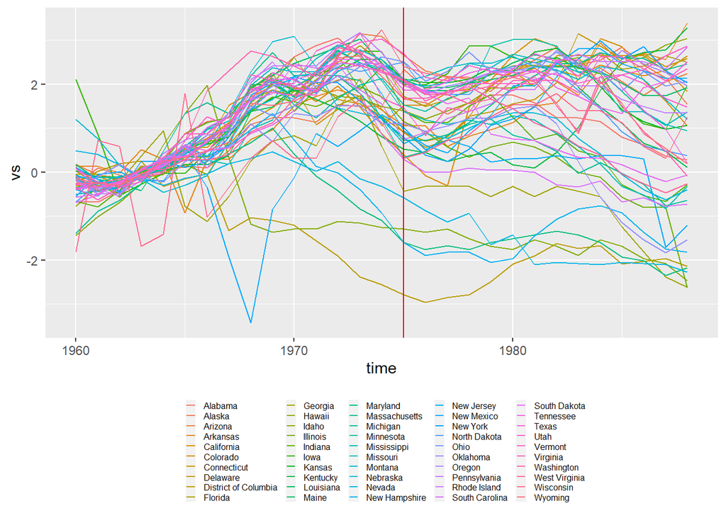

Divorce rates (standardized with overall std and means of 1961-1965)

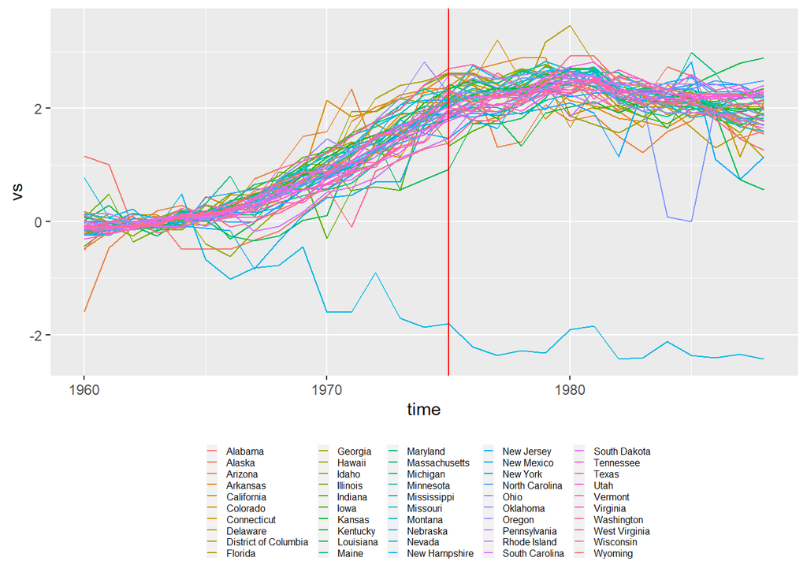

## Event dates

```r
fy <- fread(FPath("source", "FirstYearCompiledBySeiro.prn"))
d4L <- qread(FPath("save", "d4L.qs"))
m4L <- qread(FPath("save", "m4L.qs"))
setnames(fy, "state", "StateName")
fy2 <- fy[, .(StateName, year, month)]
mr <- merge(m4L, fy2, by = "StateName", all = T)
dv <- merge(d4L, fy2, by = "StateName", all = T)
```

Event year distribution

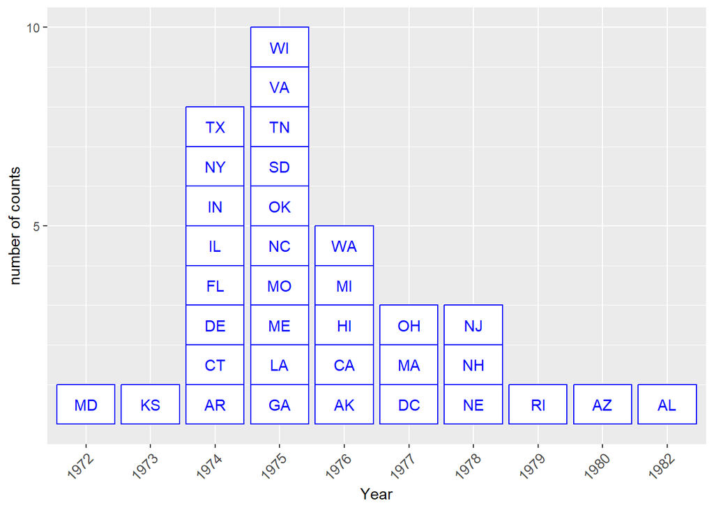

Transform data to reflect the normalisation restriction in $\eqref{eqnconst}$.

```r
for (ob in c("mr", "dv")) {
  obj = copy(get(ob))
  obj <- obj[!is.na(year), ]
  obj[, year := as.numeric(as.character(year))]
  obj[, time := as.numeric(as.character(time))]
  obj[, trend := time - min(time)+1, by = StateName]
  obj[, trend2 := trend^(2)]
  obj[, trend3 := trend^(3)]
  #### Normalization: At t-1, zero effect
  #### year is the year of first case in each state
  obj[, start := (year == time-1)]
  #### et: event time
  obj[, et := 1:.N, by = StateName]
  obj[, et := et-et[start], by = StateName]
  #### ptrend: pre-trend (after et=0, pre-trend is constant at ptrend[et==0])
  obj[, ptrend := trend]
  obj[, ptrend0 := trend[et==0], by = StateName]
  obj[et >= 0, ptrend := ptrend0]
  obj[, ptrend2 := trend2]
  obj[, ptrend20 := trend2[et==0], by = StateName]
  obj[et >= 0, ptrend2 := ptrend20]
  obj[, ptrend3 := trend3]
  obj[, ptrend30 := trend3[et==0], by = StateName]
  obj[et >= 0, ptrend3 := ptrend30]
  obj[, c("ptrend0", "ptrend20", "ptrend30") := NULL]
  qsave(obj, paste0(pathsave, ob, ".qs"))
  #### Normalization: mean of trend at event time < -1 is zero
  #### For this operation, keep dummy data matrix separately as etdum.
  etdum <- makeDummyFromFactor(factor(obj[, et]), nameprefix = "et")
   #### change to easier-to-handle names
  setnames(etdum, grepout("-", colnames(etdum)),
    gsub("-", "N", grepout("-", colnames(etdum))))
   #### Subtract t-L (set L=10) period to impose \bar{gamma}_{s<0} = 0
  negtime <- grepout("N", colnames(etdum))
  etdum[, (negtime) := lapply(.SD, function(x) x-etN10), .SDcols = negtime]
  etdum[, etN10 := NULL]
  #### Forcing mannually a specific order in factor levels.
  #### lm drops the first factor level as a reference.
  #### (can also be done using library(forcats), but not necessary)
   #### et: -1, -22 (or -23), -21 (or -20), ..., -2, 0, 1, ...
   #### time: 1988, 1958, 1959, ..., 1987.
   #### StateName: Hawaii, Alabama, ..., Washington, Florida
  obj[, et := factor(et, levels = c(-1, unique(et)[!(unique(et) %in% -1)]))]
  obj[, time := factor(time,
    levels = c(1988, unique(time)[!(unique(time) %in% c(1988, 1987))], 1987))]
  obj[, StateName := factor(StateName,
    levels = c("Hawaii",
      unique(StateName)[!(unique(StateName) %in% c("Hawaii", "Florida"))], "Florida"))]
  assign(ob, obj)
  assign(paste0(ob, "et"), etdum)
}
```

# A technical note on how R’s `lm` works using simulated data

## Multiple factors

In a regression with no intercept with mutilple factor variables, there is a rule in the choice of reference levels in `lm`.

- The first factor variable in the formula uses all factor levels.
- Other factor variables in the formula drop each of the first level.

```r
set.seed(100)
#### 10 groups (a, .., t), 60 periods
dm1 <- factor(rep(letters[1:10], each = 60))
trend <- rep(1:60, 10)
dmf <- NULL
for (gg in 1:10) {
  dm1 <- letters[gg]
  trend <- 1:60
  dm2 <- factor(sample(1:4, 60, replace = T))
  dm3 <- factor(sample(1:4, 60, replace = T))
  dm4 <- factor(sample(1:4, 60, replace = T))
  dm5 <- factor(sample(1:4, 60, replace = T))
  dm6 <- factor(sample(1:4, 60, replace = T))
  dmf0 <- data.table(y=trend+as.numeric(dm2)*9-as.numeric(dm3)*3
    -as.numeric(dm4)*6+as.numeric(dm5)*2
    -as.numeric(dm3)*1.5+rnorm(60, 0, 10),
    id=dm1, trend, dm2, dm3, dm4, dm5, dm6)
  dmf <- rbind(dmf, dmf0)
}
dmf[, id := factor(id)]
dm <- lapply(dmf[, -c(1, 3)], makeDummyFromFactor,
  reference = NULL, nameprefix = "")
lapply(2:length(dm), function(i)
  setnames(dm[[i]], paste0("d", i, colnames(dm[[i]]))))
```

```r
dm <- data.table(Reduce(cbind, dm))
summary(dm)
```

```
Rank is 25, number of columns is 30,
need to drop one level from each 5 variables
in a matrix of 5 dummy variables.
```

```r
dm[, y := dmf[, y]]
lmd0 <- lm(y ~ -1 + id + dm2 + dm3 + dm4 + dm5 + dm6, data = dmf)
DFInlm <- summary(lmd0)$df
#### Taken from stats:::print.summary.lm
if (nsingular <- DFInlm[3L] - DFInlm[1L])
  cat("\nCoefficients: (",
    nsingular, " not defined because of singularities)\n")
```

## Multiple factors with interactions

```r
lmd1 <- lm(y ~ -1 + id:dm2:dm3 + dm4 + dm5 + dm6, data = dmf)
DFInlm <- summary(lmd1)$df
#### Taken from stats:::print.summary.lm
if (nsingular <- DFInlm[3L] - DFInlm[1L])
  cat("\nCoefficients: (",
    nsingular, " not defined because of singularities)\n")
```

```
Coefficients: ( 4  not defined because of singularities)
```

```r
lmdc <- lmd1$coefficients
allco <- as.vector(unlist(
  unique(dmf[, .(int=as.character(interaction(id, dm2, dm3, sep = ":")))][order(int)])))
allco <- gsub("(.):(.):", "id\\1:dm2\\2:dm3", allco)
#### Lacking 3 in dm3
dmf[id == "h" & dm2 == 2, .(id, dm2, dm3)]
```

```
   id dm2 dm3
1:  h   2   2
2:  h   2   2
3:  h   2   1
4:  h   2   4
5:  h   2   1
6:  h   2   4
7:  h   2   2
8:  h   2   1
```

Singularity is caused by lack of multiple observations for a particular combination of interactions.

Double interactions attempted by lm

- ida:dm21:dm31, idb:dm21:dm31, idc:dm21:dm31, idd:dm21:dm31, ide:dm21:dm31, idf:dm21:dm31, idg:dm21:dm31, idh:dm21:dm31, idi:dm21:dm31, idj:dm21:dm31, ida:dm22:dm31, idb:dm22:dm31, idc:dm22:dm31, idd:dm22:dm31, ide:dm22:dm31, idg:dm22:dm31, idh:dm22:dm31, idi:dm22:dm31, idj:dm22:dm31, ida:dm23:dm31, idb:dm23:dm31, idc:dm23:dm31, idd:dm23:dm31, ide:dm23:dm31, idf:dm23:dm31, idg:dm23:dm31, idh:dm23:dm31, idi:dm23:dm31, idj:dm23:dm31, ida:dm24:dm31, idb:dm24:dm31, idc:dm24:dm31, idd:dm24:dm31, ide:dm24:dm31, idf:dm24:dm31, idg:dm24:dm31, idh:dm24:dm31, idi:dm24:dm31, idj:dm24:dm31, ida:dm21:dm32, idb:dm21:dm32, idc:dm21:dm32, idd:dm21:dm32, ide:dm21:dm32, idf:dm21:dm32, idg:dm21:dm32, idh:dm21:dm32, idi:dm21:dm32, idj:dm21:dm32, ida:dm22:dm32, idb:dm22:dm32, idc:dm22:dm32, idd:dm22:dm32, ide:dm22:dm32, idf:dm22:dm32, idg:dm22:dm32, idh:dm22:dm32, idi:dm22:dm32, idj:dm22:dm32, ida:dm23:dm32, idb:dm23:dm32, idc:dm23:dm32, idd:dm23:dm32, ide:dm23:dm32, idf:dm23:dm32, idg:dm23:dm32, idh:dm23:dm32, idi:dm23:dm32, idj:dm23:dm32, ida:dm24:dm32, idb:dm24:dm32, idc:dm24:dm32, idd:dm24:dm32, ide:dm24:dm32, idf:dm24:dm32, idg:dm24:dm32, idh:dm24:dm32, idi:dm24:dm32, idj:dm24:dm32, ida:dm21:dm33, idb:dm21:dm33, idc:dm21:dm33, idd:dm21:dm33, ide:dm21:dm33, idf:dm21:dm33, idg:dm21:dm33, idh:dm21:dm33, idi:dm21:dm33, idj:dm21:dm33, ida:dm22:dm33, idb:dm22:dm33, idc:dm22:dm33, idd:dm22:dm33, ide:dm22:dm33, idf:dm22:dm33, idg:dm22:dm33, idi:dm22:dm33, idj:dm22:dm33, ida:dm23:dm33, idb:dm23:dm33, idc:dm23:dm33, idd:dm23:dm33, ide:dm23:dm33, idf:dm23:dm33, idg:dm23:dm33, idh:dm23:dm33, idi:dm23:dm33, idj:dm23:dm33, ida:dm24:dm33, idb:dm24:dm33, idc:dm24:dm33, idd:dm24:dm33, ide:dm24:dm33, idf:dm24:dm33, idg:dm24:dm33, idh:dm24:dm33, idi:dm24:dm33, idj:dm24:dm33, ida:dm21:dm34, idb:dm21:dm34, idc:dm21:dm34, idd:dm21:dm34, ide:dm21:dm34, idf:dm21:dm34, idg:dm21:dm34, idh:dm21:dm34, idi:dm21:dm34, idj:dm21:dm34, ida:dm22:dm34, idb:dm22:dm34, idc:dm22:dm34, idd:dm22:dm34, ide:dm22:dm34, idf:dm22:dm34, idg:dm22:dm34, idh:dm22:dm34, idj:dm22:dm34, ida:dm23:dm34, idb:dm23:dm34, idc:dm23:dm34, idd:dm23:dm34, ide:dm23:dm34, idf:dm23:dm34, idg:dm23:dm34, idh:dm23:dm34, idi:dm23:dm34, idj:dm23:dm34, ida:dm24:dm34, idb:dm24:dm34, idc:dm24:dm34, idd:dm24:dm34, ide:dm24:dm34, idf:dm24:dm34, idg:dm24:dm34, idh:dm24:dm34, idi:dm24:dm34, idj:dm24:dm34.

All possible double interactions

- ida:dm21:dm31, ida:dm21:dm32, ida:dm21:dm33, ida:dm21:dm34, ida:dm22:dm31, ida:dm22:dm32, ida:dm22:dm33, ida:dm22:dm34, ida:dm23:dm31, ida:dm23:dm32, ida:dm23:dm33, ida:dm23:dm34, ida:dm24:dm31, ida:dm24:dm32, ida:dm24:dm33, ida:dm24:dm34, idb:dm21:dm31, idb:dm21:dm32, idb:dm21:dm33, idb:dm21:dm34, idb:dm22:dm31, idb:dm22:dm32, idb:dm22:dm33, idb:dm22:dm34, idb:dm23:dm31, idb:dm23:dm32, idb:dm23:dm33, idb:dm23:dm34, idb:dm24:dm31, idb:dm24:dm32, idb:dm24:dm33, idb:dm24:dm34, idc:dm21:dm31, idc:dm21:dm32, idc:dm21:dm33, idc:dm21:dm34, idc:dm22:dm31, idc:dm22:dm32, idc:dm22:dm33, idc:dm22:dm34, idc:dm23:dm31, idc:dm23:dm32, idc:dm23:dm33, idc:dm23:dm34, idc:dm24:dm31, idc:dm24:dm32, idc:dm24:dm33, idc:dm24:dm34, idd:dm21:dm31, idd:dm21:dm32, idd:dm21:dm33, idd:dm21:dm34, idd:dm22:dm31, idd:dm22:dm32, idd:dm22:dm33, idd:dm22:dm34, idd:dm23:dm31, idd:dm23:dm32, idd:dm23:dm33, idd:dm23:dm34, idd:dm24:dm31, idd:dm24:dm32, idd:dm24:dm33, idd:dm24:dm34, ide:dm21:dm31, ide:dm21:dm32, ide:dm21:dm33, ide:dm21:dm34, ide:dm22:dm31, ide:dm22:dm32, ide:dm22:dm33, ide:dm22:dm34, ide:dm23:dm31, ide:dm23:dm32, ide:dm23:dm33, ide:dm23:dm34, ide:dm24:dm31, ide:dm24:dm32, ide:dm24:dm33, ide:dm24:dm34, idf:dm21:dm31, idf:dm21:dm32, idf:dm21:dm33, idf:dm21:dm34, idf:dm22:dm32, idf:dm22:dm33, idf:dm22:dm34, idf:dm23:dm31, idf:dm23:dm32, idf:dm23:dm33, idf:dm23:dm34, idf:dm24:dm31, idf:dm24:dm32, idf:dm24:dm33, idf:dm24:dm34, idg:dm21:dm31, idg:dm21:dm32, idg:dm21:dm33, idg:dm21:dm34, idg:dm22:dm31, idg:dm22:dm32, idg:dm22:dm33, idg:dm22:dm34, idg:dm23:dm31, idg:dm23:dm32, idg:dm23:dm33, idg:dm23:dm34, idg:dm24:dm31, idg:dm24:dm32, idg:dm24:dm33, idg:dm24:dm34, idh:dm21:dm31, idh:dm21:dm32, idh:dm21:dm33, idh:dm21:dm34, idh:dm22:dm31, idh:dm22:dm32, idh:dm22:dm34, idh:dm23:dm31, idh:dm23:dm32, idh:dm23:dm33, idh:dm23:dm34, idh:dm24:dm31, idh:dm24:dm32, idh:dm24:dm33, idh:dm24:dm34, idi:dm21:dm31, idi:dm21:dm32, idi:dm21:dm33, idi:dm21:dm34, idi:dm22:dm31, idi:dm22:dm32, idi:dm22:dm33, idi:dm23:dm31, idi:dm23:dm32, idi:dm23:dm33, idi:dm23:dm34, idi:dm24:dm31, idi:dm24:dm32, idi:dm24:dm33, idi:dm24:dm34, idj:dm21:dm31, idj:dm21:dm32, idj:dm21:dm33, idj:dm21:dm34, idj:dm22:dm31, idj:dm22:dm32, idj:dm22:dm33, idj:dm22:dm34, idj:dm23:dm31, idj:dm23:dm32, idj:dm23:dm33, idj:dm23:dm34, idj:dm24:dm31, idj:dm24:dm32, idj:dm24:dm33, idj:dm24:dm34.

Dropped from formula before regression (not attempted) in care of singularity

- .

Dropped ex post due to singularity (despite attempted)

- idf:dm22:dm31, idh:dm22:dm33, idi:dm22:dm34, idj:dm24:dm34 which is the same as idj:dm24:dm34.

The above is coded as `names(lmdc[is.na(lmdc)])` which is the same as `allco[allco %in% names(lmdc[is.na(lmdc)])]`.

## Multiple factors with trend and interactions

```r
#### Add time trend, group wise time trend
setkey(dmf, id, trend)
for (aa in letters[1:20]) {
  gt <- paste0(aa, "t")
  dmf[, (gt) := 0L]
  dmf[grepl(aa, id), (gt) := 1:.N]
}
dmf
lmd2 <- lm(y ~ -1 + id*trend*dm2 + id*trend*dm3 + id*trend*dm4
  + id*trend*dm5 + id*trend*dm6, data = dmf)
DFInlm <- summary(lmd2)$df
if (nsingular <- DFInlm[3L] - DFInlm[1L])
  cat("\nCoefficients: (",
    nsingular, " not defined because of singularities)\n")
```

- Keeps all levels of `id`.
- Drops the first level of all factors.

  E.g., the first level (`dm21`) of `dm2`.
- Drops all interaction terms with dropped factor levels.

  E.g., `id:dm21`(=`ida:dm21`, .., `idj:dm21`), `trend:dm21`, `id:dm31`, `trend:dm31`.
- Drops any double interaction terms using dropped factor levels.

  Anything with `id21`, `id31`, `id41`, `id51`, e.g., `idj:dm51:trend`.
- Drops the first level of interaction terms.

```r
lmdc <- lmd2$coefficients
allco <- as.vector(unlist(
  unique(dmf[, .(int=as.character(interaction(id, dm2, sep = ":")))
  ][order(int)])))
allco <- gsub("(.):", "id\\1:trend:dm2", allco)
```

Dropped for `dm2`: Anything with `dm21` and anything with `ida:trend`.

Double interactions involving `dm2` attempted by lm

- idb:trend:dm22, idc:trend:dm22, idd:trend:dm22, ide:trend:dm22, idf:trend:dm22, idg:trend:dm22, idh:trend:dm22, idi:trend:dm22, idj:trend:dm22, idb:trend:dm23, idc:trend:dm23, idd:trend:dm23, ide:trend:dm23, idf:trend:dm23, idg:trend:dm23, idh:trend:dm23, idi:trend:dm23, idj:trend:dm23, idb:trend:dm24, idc:trend:dm24, idd:trend:dm24, ide:trend:dm24, idf:trend:dm24, idg:trend:dm24, idh:trend:dm24, idi:trend:dm24, idj:trend:dm24.

All possible double interactions involving `dm2`

- ida:trend:dm21, ida:trend:dm22, ida:trend:dm23, ida:trend:dm24, idb:trend:dm21, idb:trend:dm22, idb:trend:dm23, idb:trend:dm24, idc:trend:dm21, idc:trend:dm22, idc:trend:dm23, idc:trend:dm24, idd:trend:dm21, idd:trend:dm22, idd:trend:dm23, idd:trend:dm24, ide:trend:dm21, ide:trend:dm22, ide:trend:dm23, ide:trend:dm24, idf:trend:dm21, idf:trend:dm22, idf:trend:dm23, idf:trend:dm24, idg:trend:dm21, idg:trend:dm22, idg:trend:dm23, idg:trend:dm24, idh:trend:dm21, idh:trend:dm22, idh:trend:dm23, idh:trend:dm24, idi:trend:dm21, idi:trend:dm22, idi:trend:dm23, idi:trend:dm24, idj:trend:dm21, idj:trend:dm22, idj:trend:dm23, idj:trend:dm24.

Dropped from formula before regression (not attempted) in care of singularity

- ida:trend:dm21, ida:trend:dm22, ida:trend:dm23, ida:trend:dm24, idb:trend:dm21, idc:trend:dm21, idd:trend:dm21, ide:trend:dm21, idf:trend:dm21, idg:trend:dm21, idh:trend:dm21, idi:trend:dm21, idj:trend:dm21.

Dropped ex post due to singularity (despite attempted) (none)

- which is the same as .

ida:trend:dm22, ida:trend:dm23, ida:trend:dm24 are the dropped terms to avoid collinearity between `id`, `trend`, `dm2Y` for Y=2, …, 4.

# Effects of normalisation choice

If we use `et` variable as the first regressor, `lm` uses all levels of `et`. This overparameterises the model and gives rise to multicollinearity. In such case, we need to drop one more event time manually.

**Click here to see how reference period choice affects estimated results.**

## Baseline $\delta_{-1}=0$ vs. Miller recommend $\bar{\delta}_{<0}=0$

```r
summary(dv[, .(StateName, v, et, time, trend, trend2, trend3)])
```

```
      StateName         v              et           time         trend
 Hawaii    : 30   Min.   :0.40   -1     : 34   1988   : 34   Min.   : 1.0
 Alabama   : 30   1st Qu.:2.60   -14    : 34   1959   : 34   1st Qu.: 8.0
 Alaska    : 30   Median :3.90   -13    : 34   1960   : 34   Median :15.5
 Arizona   : 30   Mean   :4.05   -12    : 34   1961   : 34   Mean   :15.5
 Arkansas  : 30   3rd Qu.:5.30   -11    : 34   1962   : 34   3rd Qu.:23.0
 California: 30   Max.   :9.30   -10    : 34   1963   : 34   Max.   :30.0
 (Other)   :840                  (Other):816   (Other):816
     trend2        trend3
 Min.   :  1   Min.   :    1
 1st Qu.: 64   1st Qu.:  512
 Median :240   Median : 3736
 Mean   :315   Mean   : 7208
 3rd Qu.:529   3rd Qu.:12167
 Max.   :900   Max.   :27000
```

```r
obj = copy(dv)
#### In regression with no intercept,
#### lm keeps all levels in the 1st factor variable in the formula.
#### lm drops 1st levels in the 2nd factor variable in the formula.
#### lm drops 1st and last levels in the 3rd factor variable in the formula.
 #### event time, factors
#### "v" is divorce/marriage rate (not standardised)
r10a <- lm(v ~ -1+et+StateName+time, data = obj)
r10b <- lm(v ~ -1+StateName+et+time, data = obj)
r10c <- lm(v ~ -1+StateName+time+et, data = obj)
obj[, time := factor(time,
    levels = c(1988, levels(time)[!(levels(time) %in% c(1988, 1959:1961))], 1961:1959))]
 #### event time, factors, trends
r22a <- lm(v ~ -1+et+trend+trend2+trend3+StateName+time, data = obj)
r22b <- lm(v ~ -1+trend+trend2+trend3+StateName+et+time, data = obj)
r22c <- lm(v ~ -1+trend+trend2+trend3+StateName+time+et, data = obj)
 #### Create a dummy matrix of factor variable "et"
etdumpre <- makeDummyFromFactor(factor(obj[, et]), nameprefix = "et")
setnames(etdumpre, grepout("-", colnames(etdumpre)),
  gsub("-", "N", grepout("-", colnames(etdumpre))))
 #### Subtract t-L, L=10 period to impose \bar{gamma}_{s<0} = 0
negtime <- grepout("N", colnames(etdumpre))
etdumpre[, (negtime) := lapply(.SD, function(x) x-etN10), .SDcols = negtime]
etdumpre[, etN10 := NULL]
 #### formula terms for et dummy matrix
ettermspre <- paste(colnames(etdumpre), collapse = "+")
####obj[, StateName := factor(StateName,
####  exclude=c('Hawaii', 'Florida', 'District Of Columbia'))]
obj3 <- data.table(obj, etdumpre)
 #### factors, trends, explicit event time dummies
form1 <- paste0("v ~ -1+StateName+time+", ettermspre)
form2 <- paste0("v ~ -1+trend+StateName+time+", ettermspre)
form3 <- paste0("v ~ -1+trend+trend2+trend3+StateName+time+", ettermspre)
r31 <- lm(as.formula(form1), data = obj3)
r32 <- lm(as.formula(form2), data = obj3)
r33 <- lm(as.formula(form3), data = obj3)
```

Compare r10a, r10b, r10c, r22a, r22b, r22c, r31, r32, r33.

```r
#### explanation of forms
form0 <- c(
  #### r10
  "et+StateName+time", "StateName+et+time", "StateName+time+et",
  #### r22
  "et+trend+trend2+trend3+StateName+time",
  "trend+trend2+trend3+StateName+et+time",
  "trend+trend2+trend3+StateName+time+et",
  #### r3X
  "StateName+time+eterms",
  "trend+StateName+time+eterms",
  "trend+trend2+trend3+StateName+time+eterms")
#### explanation of term order
forder <- c(paste(rep(c("TWFE", "TWFE trend"), each = 3),
  c("et pos 1", "et pos 2", "et pos last")),
  "TWFE premean = 0", "TWFE trend premean = 0",
  "TWFE trend3 premean = 0")
#### explanation of normalization choice
 #### TWFE and TWFE trend use default normalization of factor level order
 #### r10a: all levels of et are used, r10b: first level of et is dropped, etc.
 #### r31-r33: etN10 is dropped, r32-r33: time is dropped in favor of trend
normalization <- c(rep(c("TWFE", "TWFE trend"), each = 3),
  rep("TWFE trend premean = 0", 3))
nums <- c(rep(c(10, 22), each =3), 31:33)
Ci <- NULL
for (i in 1:9) {
  if (i < 7)
    rr <- get(paste0("r", nums[i], rep(letters[1:3], 2)[i])) else
    rr <- get(c("r31", "r32", "r33")[i-6])
  clus <- data.table(rr$model)[, StateName]
  rrc <- clx(rr, cluster = clus, returnV = T)
  clxci <- data.table(cbind(Coef = rownames(rrc$ci), rrc$est, rrc$ci))
  clxci <- rbind(clxci, t(c(-1, 0, rep(NA, 5))), use.names = F)
  clxci[, FormulaOrder := forder[i]]
  clxci[, normalisation := normalization[i]]
  Ci <- rbind(Ci, clxci)
}
Ci[, period := gsub("et", "", Coef)]
Ci <- Ci[grepl("^.?\\d", period), ]
Ci[, period := gsub("N", "-", period)]
Ci[, period := as.numeric(period)]
setcolorder(Ci,
 c("Coef", "Estimate", "Std. Error", "t value", "Pr(>|t|)", "2.5 %", "97.5 %", "period"))
setnames(Ci, c("Estimate", "2.5 %", "97.5 %"), c("beta", "CI_L", "CI_U"))
numcols <- c("beta", "CI_L", "CI_U", "period")
Ci[, (numcols) := lapply(.SD, as.numeric), .SDcols = numcols]
strcols <- colnames(Ci)[!(colnames(Ci) %in% numcols)]
Ci[, (strcols) := lapply(.SD, factor), .SDcols = strcols]
Ci[, FormulaOrder := factor(FormulaOrder, levels = forder)]
```

**et pos X** = `et` is positioned at X. X = 1 means `et` comes first in the formula. X = 2 means `et` comes after trend and StateName. X = last means `et` comes after trend, StateName, and time.

Impacts on divorce rates: Different normalization

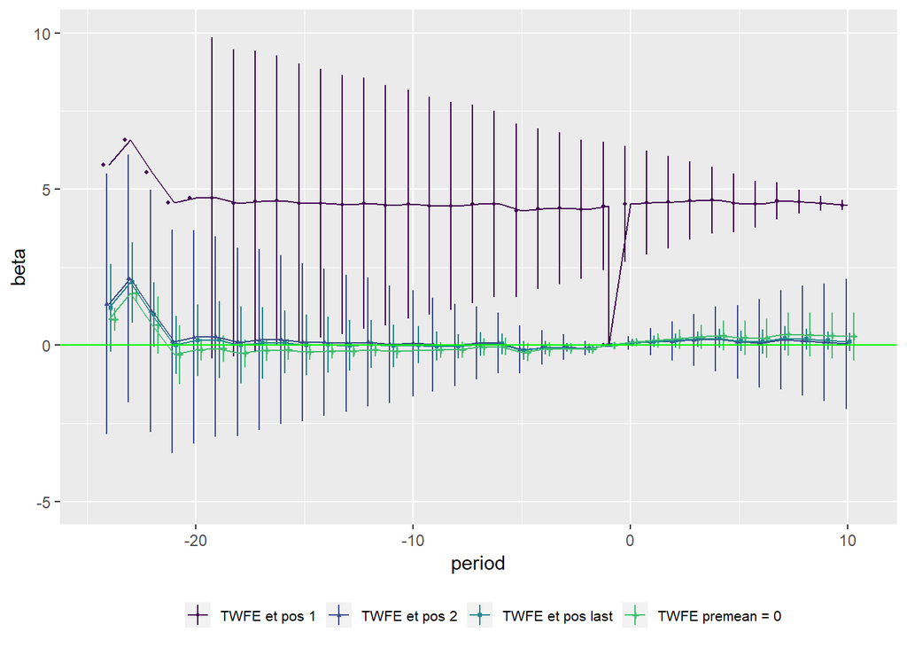

Compare r10a(TWFE et pos 1), r10b(TWFE et pos 2), r10c(TWFE et pos last).

- r10a vs r10b, r10c: One sees that keeping all levels adds a value equivalent to the intercept to all estimates. This gives a problem when we force a normalisation $\gamma_{-1}=0$ as the estimates jump around $t=-1$. Another noticeable characteristic is that standard errors decrease as event time progresses.

## With trends: $\delta_{-1}=0$ vs. $\bar{\delta}_{<0}=0$

Impacts on divorce rates: Different normalization with trends

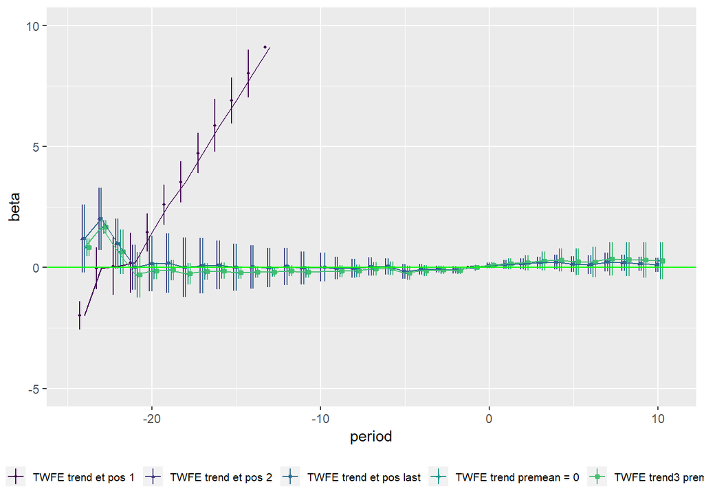

Compare r22a(TWFE trend et pos 1), r22b(TWFE trend et pos 2), r22c(TWFE trend et pos last), r31(TWFE premean = 0), r32(TWFE trend premean = 0), r33(TWFE trend3 premean = 0).

- r22a vs. r22b, r22c: When et assumes the role of intercept (r22a), it has to counter the rapid decline caused by the trend, thence an increasing pattern of estimated values as time passes. This must be avoided. Both r22b and r22c drop et=-1 and et=15. All estimates of r22b and r22c are identical.
- r31: Only N10 is dropped. r32: N10 and time are dropped.

If we exclude r10a and r22a, estimates are much similar.

Impacts on divorce rates: Different normalization with event time factor defined as deviation from overall mean

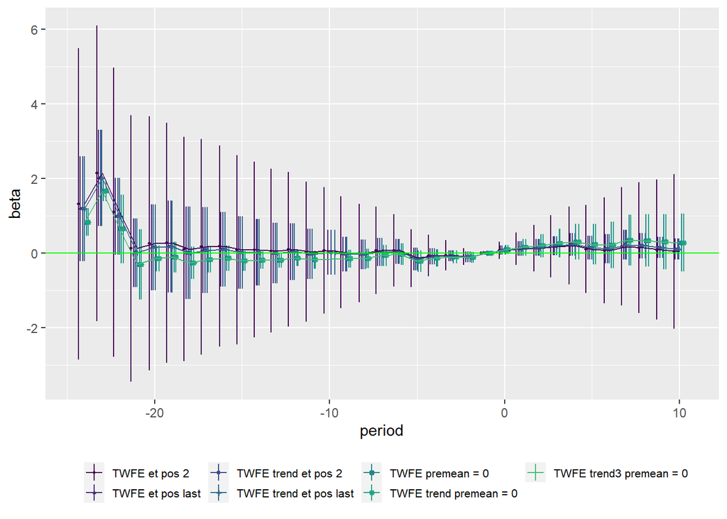

- Differences in point estimates are difference in normalization choice, $\delta_{-1}=0$ or $\bar{\delta}_{\tau<0}=0$.
- Such seemingly an inoccuous choice has big impacts on standard errors. Premean = 0 seems to enjoy tighter CIs. This was also pointed out in Miller saying basing on one point involves larger sampling errors, but I am not sure if such reasoning is convincing.

Impacts on divorce rates: Premean = 0 normalization

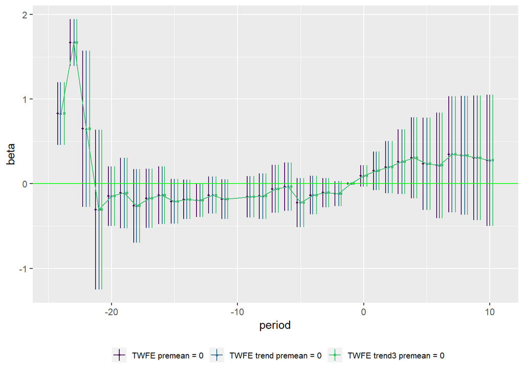

What if we only use 1961- and etN19-et15?

```r
obj = copy(dv)
r10a <- lm(v ~ -1+et+StateName+time,
  data = obj[as.numeric(as.character(time)) > 1960, ])
r10b <- lm(v ~ -1+StateName+et+time,
  data = obj[as.numeric(as.character(time)) > 1960, ])
r10c <- lm(v ~ -1+StateName+time+et,
  data = obj[as.numeric(as.character(time)) > 1960, ])
r22a <- lm(v ~ -1+et+trend+trend2+trend3+StateName+time,
  data = obj[as.numeric(as.character(time)) > 1960, ])
r22b <- lm(v ~ -1+trend+trend2+trend3+StateName+et+time,
  data = obj[as.numeric(as.character(time)) > 1960, ])
r22c <- lm(v ~ -1+trend+trend2+trend3+StateName+time+et,
  data = obj[as.numeric(as.character(time)) > 1960, ])
obj[, time := factor(time,
    levels = c(1988, levels(time)[!(levels(time) %in% c(1988, 1959:1961))], 1961:1959))]
etdumpre <- makeDummyFromFactor(factor(obj[, et]), nameprefix = "et", reference = NULL)
setnames(etdumpre, grepout("-", colnames(etdumpre)),
  gsub("-", "N", grepout("-", colnames(etdumpre))))
negtime <- grepout("N", colnames(etdumpre))
etdumpre[, (negtime) := lapply(.SD, function(x) x-etN10), .SDcols = negtime]
etdumpre[, etN10 := NULL]
ettermspre <- paste(colnames(etdumpre), collapse = "+")
obj3 <- data.table(obj, etdumpre)
ettermspre2 <- gsub("etN2..*etN20\\+", "", ettermspre)
form1 <- paste0("v ~ -1+StateName+time+", ettermspre2)
form2 <- paste0("v ~ -1+trend+StateName+time+", ettermspre2)
form3 <- paste0("v ~ -1+trend+trend2+trend3+StateName+time+", ettermspre2)
r31 <- lm(as.formula(form1), data = obj3[as.numeric(as.character(time)) > 1960, ])
r32 <- lm(as.formula(form2), data = obj3[as.numeric(as.character(time)) > 1960, ])
r33 <- lm(as.formula(form3), data = obj3[as.numeric(as.character(time)) > 1960, ])
Ci <- NULL
normalization <- c(rep(c("TWFE", "TWFE trend"), each = 3),
  rep("TWFE trend premean = 0", 3))
nums <- c(rep(c(10, 22), each =3), 31:33)
Ci <- NULL
for (i in 1:9) {
  if (i < 7)
    rr <- get(paste0("r", nums[i], rep(letters[1:3], 2)[i])) else
    rr <- get(c("r31", "r32", "r33")[i-6])
  clus <- data.table(rr$model)[, StateName]
  rrc <- clx(rr, cluster = clus, returnV = T)
  clxci <- data.table(cbind(Coef = rownames(rrc$ci), rrc$est, rrc$ci))
  if (i < 7) clxci <- rbind(clxci, t(c(-1, 0, rep(NA, 5))), use.names = F)
  clxci[, FormulaOrder := forder[i]]
  clxci[, normalisation := normalization[i]]
  Ci <- rbind(Ci, clxci)
}
Ci[, period := gsub("et", "", Coef)]
Ci <- Ci[grepl("^.?\\d|tre", period), ]
Ci[, period := gsub("N", "-", period)]
Ci[, period := as.numeric(period)]
setcolorder(Ci,
 c("Coef", "Estimate", "Std. Error", "t value", "Pr(>|t|)", "2.5 %", "97.5 %", "period"))
setnames(Ci, c("Estimate", "2.5 %", "97.5 %"), c("beta", "CI_L", "CI_U"))
numcols <- c("beta", "CI_L", "CI_U", "period")
Ci[, (numcols) := lapply(.SD, as.numeric), .SDcols = numcols]
strcols <- colnames(Ci)[!(colnames(Ci) %in% numcols)]
Ci[, (strcols) := lapply(.SD, factor), .SDcols = strcols]
Ci[, FormulaOrder := factor(FormulaOrder, levels = forder)]
Ci[grepl("pre", FormulaOrder) & abs(period) < 2,
  .(Coef, beta, period, FormulaOrder)][order(Coef, FormulaOrder)]
```

```
   Coef     beta period            FormulaOrder
1:  et0 0.661398      0        TWFE premean = 0
2:  et0 0.661398      0  TWFE trend premean = 0
3:  et0 0.661398      0 TWFE trend3 premean = 0
4:  et1 0.765569      1        TWFE premean = 0
5:  et1 0.765569      1  TWFE trend premean = 0
6:  et1 0.765569      1 TWFE trend3 premean = 0
7: etN1 0.525515     -1        TWFE premean = 0
8: etN1 0.525515     -1  TWFE trend premean = 0
9: etN1 0.525515     -1 TWFE trend3 premean = 0
```

```r
Ci[grepl("pre", FormulaOrder) & grepl("trend", Coef),
  c("Coef", "beta", "Pr(>|t|)", "FormulaOrder")][order(Coef, FormulaOrder)]
```

```
     Coef        beta           Pr(>|t|)            FormulaOrder
1:  trend  0.02886720   0.12558331462347  TWFE trend premean = 0
2:  trend  3.96516928 0.0798549729677805 TWFE trend3 premean = 0
3: trend2 -0.22953462 0.0932236296226804 TWFE trend3 premean = 0
4: trend3  0.00364198  0.105279801102284 TWFE trend3 premean = 0
```

Impacts on divorce rates: Premean = 0 normalization, 1961-

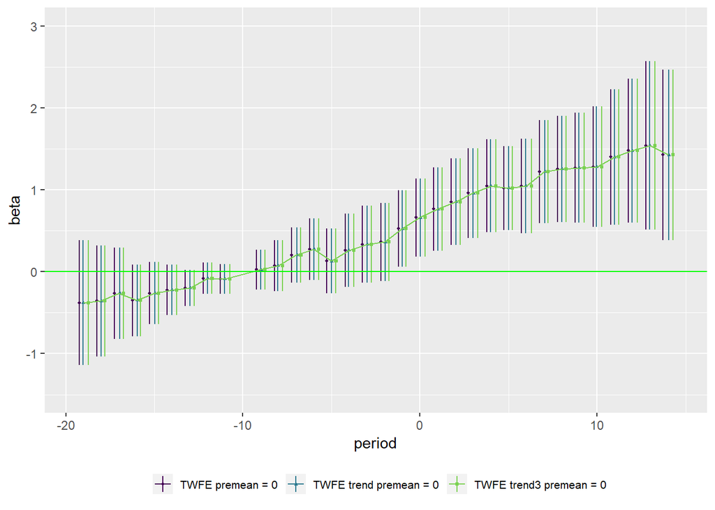

- Estimates are exactly the same for all models.
- Trend and time FEs have a linear relationship. This makes estimates on other variables exactly the same.
- When time FEs and trend are put together, we can define a new set of time FEs $\tilde{\tau}_{1} = \tau_{1} - trend$, $\tilde{\tau}_{2} = \tau_{2} - 2*trend$, … where $\tau_{t}$ is time $t$ FE in the regression without a trending term. So when time FEs and trend are used as covariates, and one of $\tau_{t}$ must be dropped to avoid collinearity with $trend$ and $\tau_{t}$.

In essence, for the divorce and marriage data sets, the only variations in estimation specification that are worths examining are:

- TWFE with $\delta_{-1}=0$, and,
- TWFE with $\bar{\delta}_{\tau<0} = 0$.
- In both, one of `et` factor levels is dropped.

Impacts on divorce rates: t=-1 and premean normalization, 1961-1987

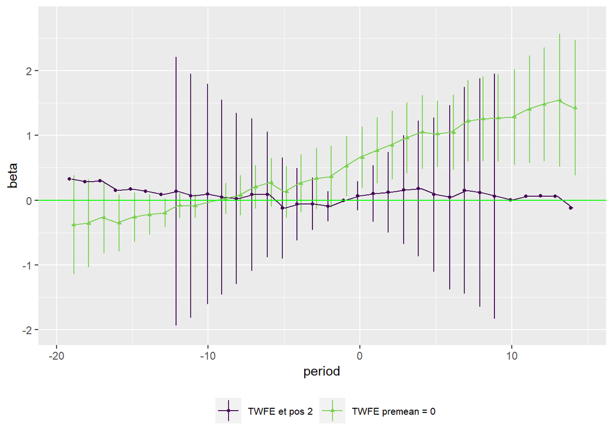

- It is essential to note the increasing trend in divorce rates when we try to understand the differences in model estimates.
- Restriction $\bar{\delta}_{\tau<0}=0$ pulls down pre-period estimates. When combined with the increasing trend, it gives rise to elevated post-period estimates.
- Using only time FEs (TWFE) stabilizes point estimates around zero, but at the cost of increasing SEs or a less precise fit.
- With smaller SEs, one would choose the model with $\bar{\delta}_{\tau<0}=0$ restriction.
- The last point may be more emphasized once we see that $\delta_{-1}=0$ and $\bar{\delta}_{<0}=0$ are a transformation of one another: If we tilt $\delta_{-1}=0$ (purple line) counter clockwise at around the point where $\bar{\delta}_{<0}=0$ (green) crosses zero, we will have the same plots. This implies smaller SEs can be a free lunch.
- There seems to be a pattern in SEs: They are smallest when the sign of estimates change (when the line cross zero).
  - $\delta_{-1}=0$ has small $p$ values right after the impact but not later.
  - Later impacts (mechanically?) have larger $p$ values.